# Coursework Report

*N* removed NAs: 2

*N* removed typo: 1

*N* removed <18: 29

*N* total clean: 118

| Group | *N* | *M*<sub>age</sub> | *M*<sub>rating</sub> |
| --- | --- | --- | --- |
| Control | 62 | 20.79 | 6.62 |
| Experim | 56 | 21.00 | 5.82 |

**Main analysis results**

*t*(116) = 5.59, *p* < .001

[interactive chart not shown]

[figure not shown]

[interactive chart not shown]

# Coursework Report

Analysing Data, Spring 2020

# Method

## *Participants*

Participants were informed that the experiment required them give their first impressions of others. This is a replication study of Elliot and colleagues’, (2010) experiment. Identical to Elliot and colleagues, (2010), in each of the three experiments, a photo of a moderately attractive man was presented, typically for 5 seconds, and then participants gave their responses. Moreover, there was a different person in the picture in each experiment. Participants were asked to rate the attractiveness of the person in the pictures on a scale ranging from 1 (**not at all attractive**) and 9 (**extremely attractive**). Participants were then debriefed and dismissed.

Table 1 *Descriptive statistics by categories of Age*

| Group | *M* | *SD*<sub>Age</sub> | Minimum | Maximum |
| --- | --- | --- | --- | --- |
| White | 20.8 | 2.15 | 18 | 27 |
| Red | 21.0 | 1.84 | 18 | 26 |

## *Design*

This is a replication of Elliot and colleagues’, (2010) study and it will be examining the reliability of their original results. The original hypothesis was that the colour red amplifies attraction to men and “does so by increasing womens’ perception of the man’s status, which enhances her attraction to him” (Elliot et al. 2010, p 402). My hypothesis and results cannot include gender variables because no gender data was collected. The hypothesis for this experiment is that the colour white will increase attraction to the men in the photographs and will do so by increasing perceptions of friendliness and purity which increases the likelihood that he may be perceived as attractive. This study has an independent groups design because participants in both conditions (red and white) only participated in one condition. To explain, the 2 independent variables were the different coloured backgrounds: Control Condition (White background) and experimental condition (Red background).The dependent variable in this study is how attractive the men are perceived to be, measured on a continuous rating scale ranging from 1 (**not at all attractive**) and 9 (**extremely attractive**).

This experiment replicates Elliot and colleagues, (2010) study design therefore the the photos used were:

> 4-in by 6-in. head and upper torso shot of a moderately attractive young Caucasian men ( one for each experiment) with brown hair wearing a plain button-down shirt; it was selected from a standard photo set (Corneille, Monin, & Pleyers, 2005, as cited in Elliot et al., 2010). The photo was centered on an 8.5-in. by 11-in. page, and color was placed on the area surrounding the photo. The parameters for red were LCh(49.6, 58.8, 30.4); white was simply the absence of additional color on the white background.

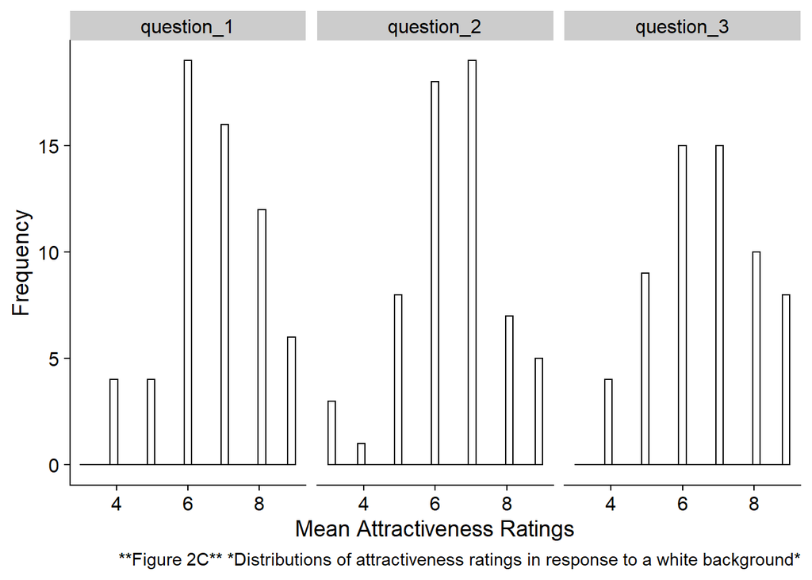

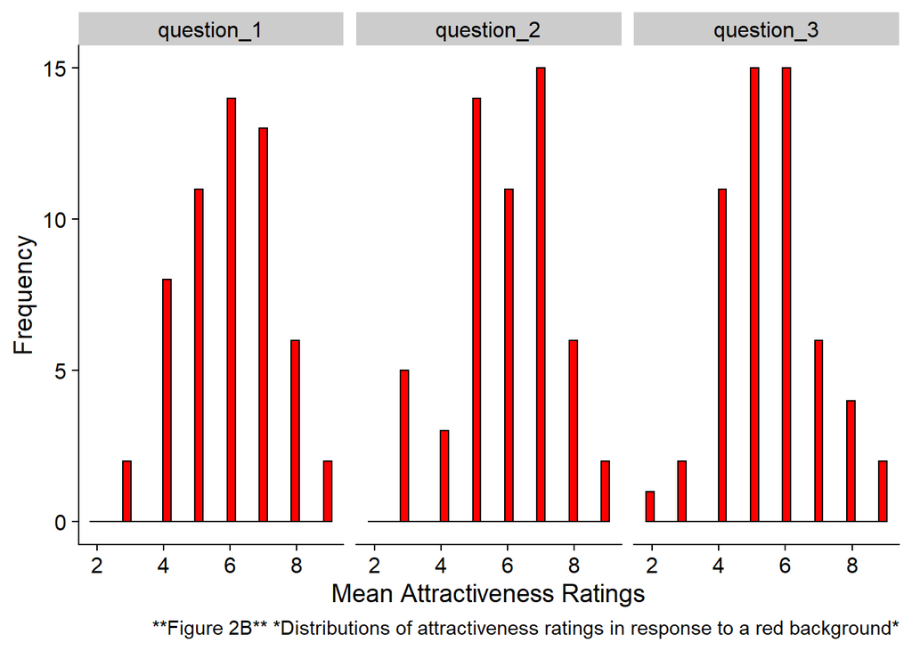

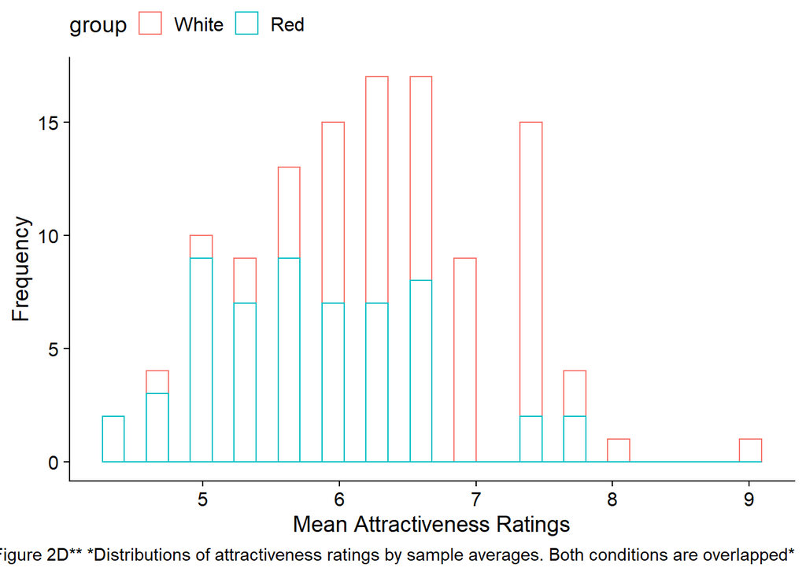

# Results

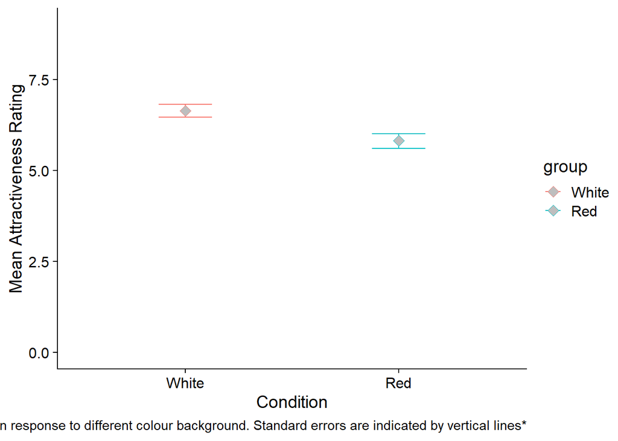

# Discussion

In summary, the results did not align with the previous study’s predictions of Elliot and colleagues, (2010). However, the results for this experiemnt do support the hypothsis, proposed above, for this experiment. This means there were higher attractiveness scores for the white background condition. Furthermore, the study shows a significant difference on how colour can change perceptions of attractiveness. This could be explained by various factors relating to the perceptions of the colours white and red.There are 3 reasons for the obtained results, including negative associations with the colour red, positive associations with the colour white, or issues with extraneous variables.  
Firstly, the reason why the colour white was considered to increase attraction rates in comparison to the colour red could be (1) due to negative associations with the colour red. For example, red is symbolically known as a dominant colour; positive and negative impressions such as strong, passionate, warm, but also aggressive, bloody and raging (Kaya & Epps, 2004). Perhaps the negative associations with aggression and rage could be considered to be unattractive qualities and therefore account for lower attractiveness ratings. To support this, Stephen and colleagues, (2012) reported that the highest levels of red was associated with aggression, specifically in relation to facial redness. In another study, participant body language concluded that individuals are more likely to respond more aversively to red stimuli in comparison to green or grey stimuli (Elliot, Maier, Binser, Friedman and Pekrun, 2009). The issue is that evidence is mixed and the colour red is also found to have cross cultural links with love and passion (Aslam, 2006; Jacobs, Koewn, Worthley, & Gyhmn, 1991, as cited in Elliot et al., 2010). Therefore, the behavioural and emotional effects of colour in this experiment may not be a valid explanation for the results of this study, which leads onto the second explanation.  
Secondly,(2) The colour white has positive associations with purity which may increase perceptions of attractiveness. There is very little research investigating the effects of this colour however white is reported to represent purity or innocence; conveys cleanliness and simplicity (Cherry, 2020). The issue is that the effects of the colour white is rarely investigated in psychological research as it is considered to be a neutral and baseline colour therefore it is difficult to determine whether there is even a positive or negative affect on the perception of attractiveness. This leads onto the third issue suggesting that neither colour is responsible for the results of the experiment.  
Lastly, (3) extraneous variables may be responsible for the significant difference between each condition. For example a prior probability may exist in relation to the features of the pictures in the study. Perhaps brown hair and certain facial expressions look more attractive against a white background, however the same face with different hair may be perceived as more attractive against a different colour background. Another issue is that this was an online study meaning that the pictures were viewed on screens. Unless each screen is at the exact same setting, it is difficult to be certain that all participants are viewing the same shades of colours which could affect perceptions of attractivness. Moreover, it is difficult to account for individual differences such as colorblindness and subjective experiences for colour associations. Overall, this means there could be numerous possibilities beyond colour variables which correspond to attractiveness ratings. This leads on to the two limitations of this study.  
Firstly, it is unclear why the colours red and white change perceptions of attractiveness which means the study lacks specificity as to what effect colour has on the human perception of attractiveness. Another limitation is that Elliot and colleagues results were not replicated in this study which indicates that this experiment lacks reliability. A reason for obtaining different results could be due to individual differences in samples.  
The implications of this research may contribute to the evidence that colour effects are able to modulate the perceptions of attraction however these results should be taken with caution due to the issues mentioned above. In future, to resolve the issues of specificity, it would be useful to collect more data about the psychological associations with the colour spectrum, especially for the colour white. Moreover, this should be approached in an operationalised manner in order to formulate more precise judgements predicting colour effect phenomenon and its influence on human behaviour.

# References

Aslam, M. M. (2006). Are you selling the right colour? A cross-cultural review of colour as a marketing cue. *Journal of Marketing Communications*,  
*12*, pp. 15–30.

Cherry, K. (2020). The Color Psychology of White. Retrieved from: https://www.verywellmind.com/color-psychology-white-2795822

Corneille, O., Monin, B., & Pleyers, G. (2005). Is positivity a cue or a response option? Warm glow vs. evaluative matching in the familiarity for  
attractive and not-so-attractive faces. *Journal of Experimental Social Psychology*, *41*, pp. 431–437.

Elliot, A. J., Maier, M. A., Binser, M. J., Friedman, R., and Pekrun, R. (2009). The effect of red on avoidance behavior in achievement contexts.  
*Personality and Social Psychology Bulletin,* *35*, pp. 365–375.

Elliot, A., Niesta Kayser, D., Greitemeyer, T., Lichtenfeld, S., Gramzow, R., Maier, M., & Liu, H. (2010). Red, Rank, and Romance in Women Viewing  
Men. *Journal of Experimental Psychology: General*, 139(*3*), pp. 399-417.

Jacobs, L., Keown, C., Worthley, R., & Gyhmn, K. (1991). Cross-cultural color comparisons: *Global marketers beware! International Marketing*  
*Review*, *8*, pp. 21–30.

Kaya N., Epps H. (2004). Relationship between color and emotion: a study of college students. *Coll. Stud. J.* *38*, pp. 396–405.

Stephen, I. D., Oldham, F. H., Perrett, D. I., & Barton, R. A. (2012). Redness Enhances Perceived Aggression, Dominance and Attractiveness in  
Men’s Faces. *Evolutionary Psychology*, 10*(3)*, pp. 562-72. Retrieved from: https://doi.org/10.1177/147470491201000312